# Red Wine Quality Analysis by Meili

In order to understand the pattern clearly, I divide the dataset into 3 intervals based on quality values: high quality (quality within 7 and 8), middle quality (quality within 5 and 6), and low quality (quality within 3 and 4).

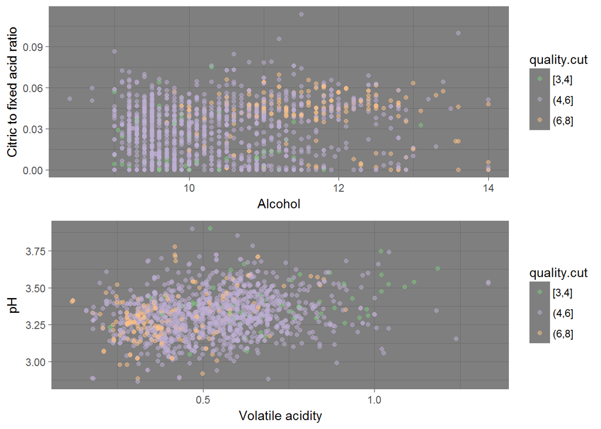

Above plots show two opposite distribution of quality clusters with different variables. The top plot shows that high quality wines usually have higher alcohol than middle quality wines, and among high quality wines, more wines would have higher citric acid to fixed acid ratio. However on the bottom plot, high quality wines tend to have lower volatile acid, and low pH, and low quality wines tend to have high volatile acid and high pH.

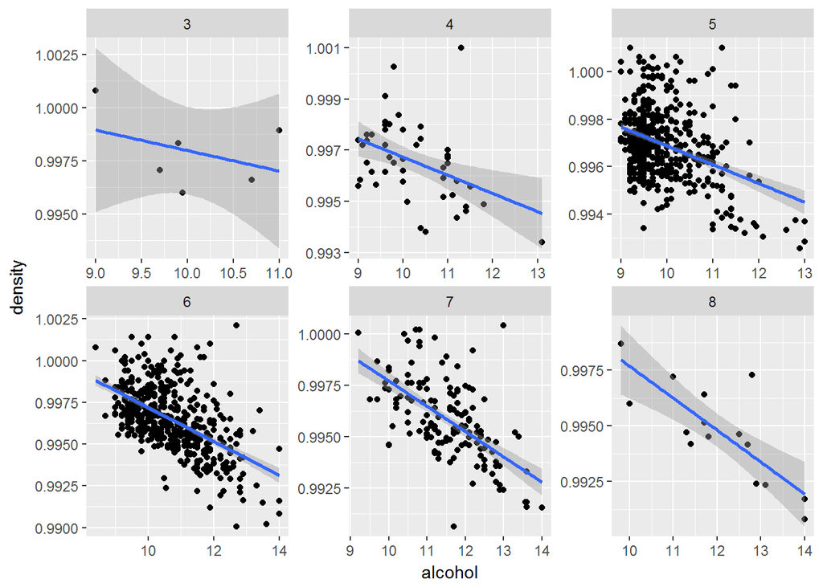

Density is the most coorelated variable with alcohol. Alcohol vs density shows varied covariance at different quality. When quality goes from low to high, the coorelation goes steeper.

```
## [1] "Result for linear regression"
```

```
##
## Call:
## lm(formula = quality ~ fixed.acidity + volatile_fixed_acid_ratio +
##     citric_fix_acid_ratio + residual.sugar + chlorides + free.sulfur.dioxide +
##     total.sulfur.dioxide + density + pH + sulphates + alcohol,
##     data = rw_remove_outlier)
##
## Residuals:
##     Min      1Q  Median      3Q     Max
## -2.7453 -0.3710 -0.0429  0.4218  1.9672
##
## Coefficients:
##                             Estimate Std. Error t value Pr(>|t|)
## (Intercept)                33.365421  23.677846   1.409 0.159012
## fixed.acidity              -0.018582   0.026259  -0.708 0.479290
## volatile_fixed_acid_ratio  -6.914085   0.964294  -7.170  1.2e-12 ***
## citric_fix_acid_ratio      -1.156193   1.188456  -0.973 0.330792
## residual.sugar             -0.017111   0.034894  -0.490 0.623937
## chlorides                  -2.627806   1.145237  -2.295 0.021904 *
## free.sulfur.dioxide         0.003814   0.002344   1.628 0.103852
## total.sulfur.dioxide       -0.002975   0.000797  -3.732 0.000197 ***
## density                   -29.098074  24.158207  -1.204 0.228604
## pH                         -0.457413   0.202940  -2.254 0.024352 *
## sulphates                   1.406340   0.140805   9.988  < 2e-16 ***
## alcohol                     0.274538   0.028887   9.504  < 2e-16 ***
## ---
## Signif. codes:  0 '***' 0.001 '**' 0.01 '*' 0.05 '.' 0.1 ' ' 1
##
## Residual standard error: 0.6258 on 1423 degrees of freedom
## Multiple R-squared:  0.3869, Adjusted R-squared:  0.3821
## F-statistic: 81.63 on 11 and 1423 DF,  p-value: < 2.2e-16
```

```
## [1] "Result for polynomial regression"
```

```
##
## Call:
## lm(formula = quality ~ poly(fixed.acidity, 2) + volatile_fixed_acid_ratio +
##     citric_fix_acid_ratio + residual.sugar + chlorides + poly(free.sulfur.dioxide,
##     2) + total.sulfur.dioxide + density + pH + sulphates + alcohol,
##     data = rw_remove_outlier)
##
## Residuals:
##     Min      1Q  Median      3Q     Max
## -2.7390 -0.3635 -0.0374  0.4188  1.9809
##
## Coefficients:
##                                 Estimate Std. Error t value Pr(>|t|)
## (Intercept)                    3.564e+01  2.400e+01   1.485   0.1377
## poly(fixed.acidity, 2)1       -9.858e-01  1.747e+00  -0.564   0.5726
## poly(fixed.acidity, 2)2        5.218e-02  6.760e-01   0.077   0.9385
## volatile_fixed_acid_ratio     -6.897e+00  9.738e-01  -7.083 2.21e-12 ***
## citric_fix_acid_ratio         -1.066e+00  1.187e+00  -0.898   0.3694
## residual.sugar                -1.527e-02  3.486e-02  -0.438   0.6614
## chlorides                     -2.674e+00  1.151e+00  -2.323   0.0203 *
## poly(free.sulfur.dioxide, 2)1  1.821e+00  8.842e-01   2.060   0.0396 *
## poly(free.sulfur.dioxide, 2)2 -1.712e+00  6.507e-01  -2.631   0.0086 **
## total.sulfur.dioxide          -3.465e-03  8.171e-04  -4.241 2.37e-05 ***
## density                       -3.139e+01  2.433e+01  -1.290   0.1972
## pH                            -4.715e-01  2.078e-01  -2.269   0.0234 *
## sulphates                      1.397e+00  1.410e-01   9.908  < 2e-16 ***
## alcohol                        2.730e-01  2.884e-02   9.465  < 2e-16 ***
## ---
## Signif. codes:  0 '***' 0.001 '**' 0.01 '*' 0.05 '.' 0.1 ' ' 1
##
## Residual standard error: 0.6247 on 1421 degrees of freedom
## Multiple R-squared:  0.3899, Adjusted R-squared:  0.3843
## F-statistic: 69.85 on 13 and 1421 DF,  p-value: < 2.2e-16
```

```
## 'data.frame':    718 obs. of  6 variables:
##  $ 3: num  0.001658 0.003896 0.001916 0.000214 0.001562 ...
##  $ 4: num  0.1222 0.0291 0.0422 0.0212 0.1097 ...
##  $ 5: num  0.684 0.703 0.665 0.512 0.689 ...
##  $ 6: num  0.187 0.254 0.276 0.43 0.195 ...
##  $ 7: num  0.00477 0.01017 0.01489 0.03679 0.00467 ...
##  $ 8: num  1.48e-10 5.32e-07 5.31e-07 3.12e-08 7.57e-11 ...
```

```
## [1] "Accuracy using 6 individual quality is 0.582172701949861"
```

```
## 'data.frame':    718 obs. of  3 variables:
##  $ [3,4]: num  0.1253 0.0381 0.0455 0.0163 0.1086 ...
##  $ (4,6]: num  0.867 0.948 0.935 0.943 0.884 ...
##  $ (6,8]: num  0.00765 0.01428 0.01982 0.04036 0.00736 ...
```

```
## [1] "Accuracy using combined quality is 0.838440111420613"
```

# Multivariate Analysis

### Talk about some of the relationships you observed in this part of the investigation. Were there features that strengthened each other in terms of looking at your feature(s) of interest?

I found in the multivariate plots that alcohol and citric acid to fixed acid ratio together stengthened each other when changing quality positively. Similarly, volatile acid and pH together strengthened each other for the negative relationship with quality.

### OPTIONAL: Did you create any models with your dataset? Discuss the strengths and limitations of your model.

# Final Plots and Summary

### Plot One

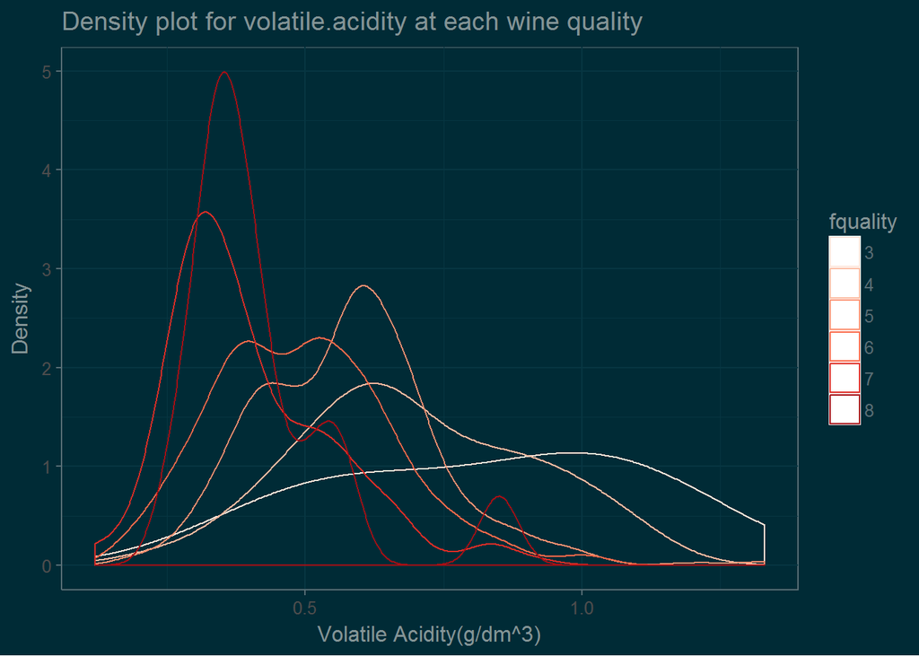

### Description One

I use density plot to check how the distribution peaks migrates for each level of quality. For example for volatile.acidity, it clears shows the center of peaks migrate to the left and peak height increases from low quality to high quality.

### Plot Two

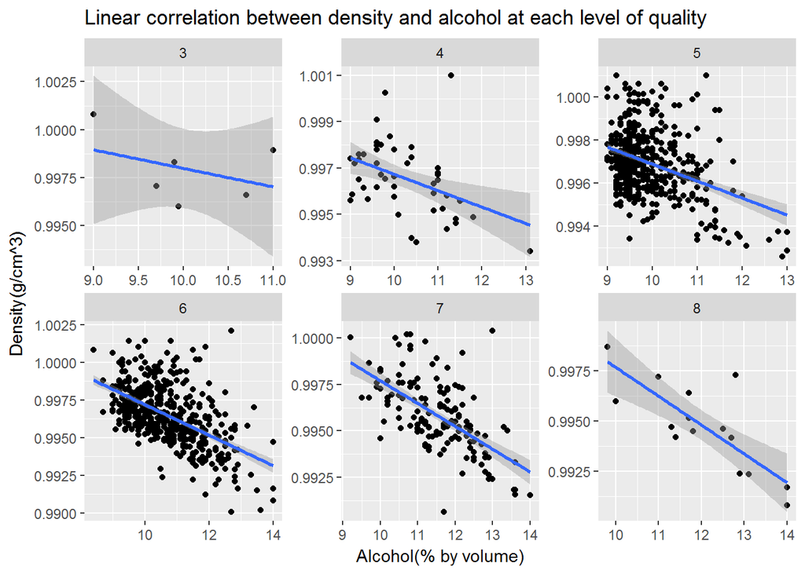

### Description Two

The linear correlationship can be varied for different quality wines. For example the slope between alcohol and density changes from vertical to horizontal from high quality to low quality.

### Plot Three

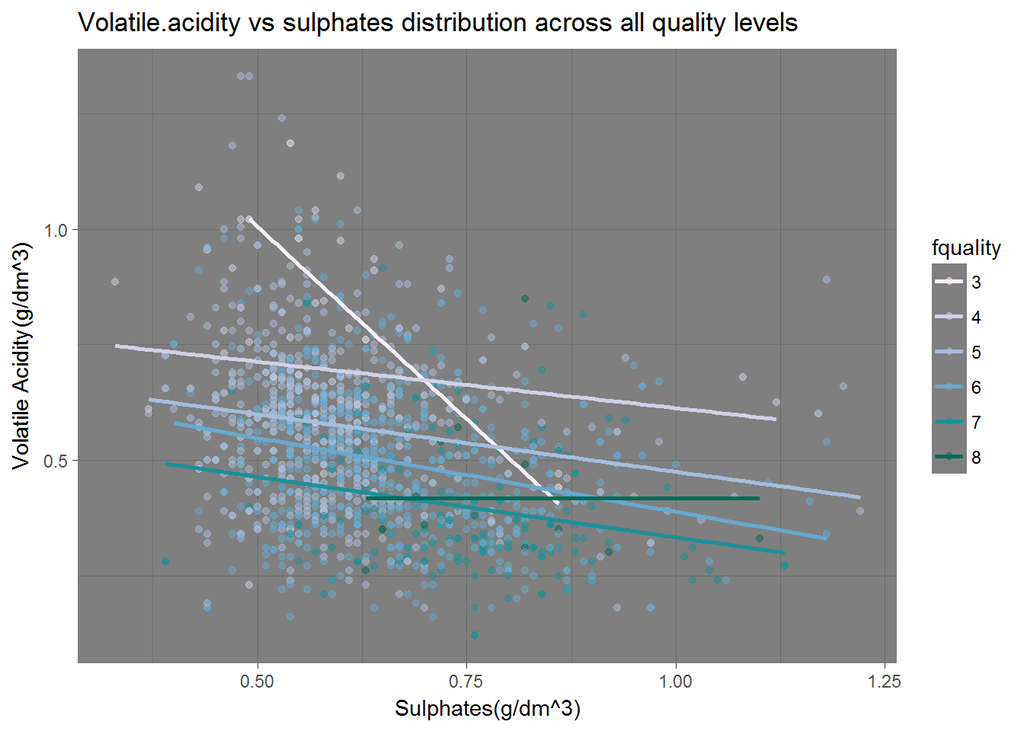

### Description Three

The last summary graph plots sulphates vs volatile.acidity with quality as color, showing high quality gathers on the right bottom along horizontal direction, and low quality gathers on the left side where sulphates are low, and vertical direction.

# Reflection

The red wine data contains 1599 observations of 13 variables. I created three additional variables using possiblely related variables. Quality is the most interested feature to investigate. The data contains many outliers and extrems for a few variables, so I deleted the outliers above Q3+1.5*IQR, resulting a more concentrated data with 1435 observations. And I use linear regression, polynomial regression and logistic regression to fit reduced dataset. Overall, multinomial logistic regression gives a better accuracy when predicting quality by three levels.

During the project I was able to use EDA skills to understand the variance of one, two or three variables, and their correlations. One future work is to plot residual from fitting of two variables, against a third variable, to understand when which variable is the dominate one or both are.

There are some limits of this analysis. Firstly, comparing to wine qualities between 5 and 6 there are much less wine qulities lay 3-4 and 7-8, which may affect the accuracy of the analysis. Secondly, I include all the variables for regression analysis. The model could be improved if removing less relative variables. Thirdly, the outliers are removed so dataset is reduced. It could also affect on the accuracy when building prediction models. Last but not least, it may help to better predict wine quality if other varialbles were given, such as tester’s informations like years of testing, or grape type etc.